# Case Study: How Can a Wellness Technology Company Play It Smart?

MW Kamdar

July 2021

## Introduction

Bellabeat is a high-tech manufacturer of products for women’s health. Their products allow users to track and monitor health-related data such as physical activity, sleep, stress and hydration to help them make better informed decisions towards achieving their personal health goals. Urška Sršen, the Chief Creative Officer (CCO) of Bellabeat, is looking to expand their presence in the smart device market.

## 1: Business Task

The task for this project is to provide the CCO with high-level recommendations to guide marketing strategy for one of Bellabeat’s smart devices. Data from fitness tracking smart devices will be used to gain insights on smart device usage and consumer behaviour. These insights will then be used to develop the recommendations.

## 2: Data Collection

The dataset to be analysed (as recommended by Sršen) is the [FitBit Fitness Tracker Data](https://www.kaggle.com/arashnic/fitbit?select=Fitabase+Data+4.12.16-5.12.16), made available by Kaggle user Mobius through the CC0: Public Domain license. As explained on the webpage, the datasets were generated by respondents to a distributed survey via Amazon Mechanical Turk between 12-03-2016 and 12-05-2016.

```r
#Import first set of files
setwd("\\..FitBitData1")
file_names <- list.files()

#Set dataframe name = "filename1"
for(i in file_names){
  assign(paste0(substr(i,1,nchar(i)-11),1), read.csv(i))
}

#Import second set of files
setwd("\\..FitBitData2")
file_names <- list.files()

for(i in file_names){
  assign(paste0(substr(i,1,nchar(i)-11),2), read.csv(i))
}
```

Here are the columns from some of the most important files:

```r
colnames(dailyActivity1)
```

```
##  [1] "Id"                       "ActivityDate"
##  [3] "TotalSteps"               "TotalDistance"
##  [5] "TrackerDistance"          "LoggedActivitiesDistance"
##  [7] "VeryActiveDistance"       "ModeratelyActiveDistance"
##  [9] "LightActiveDistance"      "SedentaryActiveDistance"
## [11] "VeryActiveMinutes"        "FairlyActiveMinutes"
## [13] "LightlyActiveMinutes"     "SedentaryMinutes"
## [15] "Calories"
```

```r
colnames(sleepDay2)
```

```
## [1] "Id"                 "SleepDay"           "TotalSleepRecords"
## [4] "TotalMinutesAsleep" "TotalTimeInBed"
```

```r
colnames(weightLogInfo1)
```

```
## [1] "Id"             "Date"           "WeightKg"       "WeightPounds"
## [5] "Fat"            "BMI"            "IsManualReport" "LogId"
```

The data comes in two sets of files, each corresponding to one month worth of data: The first set covers 12-03-2016 to 12-04-2016 and the second set covers 12-04-2016 to 12-05-2016. There are 11 files in the first set and 18 files in the second set. Upon inspecting both sets of files, there are some problems:

- **Redundancy**: The data from the daily calories, intensities, and steps files are already incorporated in the daily activities file.
- **Irrelevent data**: The tracking by minute data is overly detailed, as hourly tracking is sufficient for daily trend analysis.
- **Mergeable data spread across files**: The hourly calories, intensities and steps files can be merged into an hourly activities file. The seperate data files for each month can be appended together as well.
- **Some files contain too few samples to draw meaningful analysis from**: The file on weight logs only has data from 11 users, of which only three had more than one entry:

```r
weightLogInfo1 %>% group_by(Id) %>% summarise(n())
```

```
## # A tibble: 11 x 2
##            Id `n()`
##         <dbl> <int>
##  1 1503960366     1
##  2 1927972279     1
##  3 2347167796     1
##  4 2873212765     2
##  5 2891001357     1
##  6 4445114986     1
##  7 4558609924     1
##  8 4702921684     1
##  9 6962181067    14
## 10 8253242879     1
## 11 8877689391     9
```

The files contain data on physical activity, calories burned, steps walked, and sleep. Publically available datasets on fitness tracking data were investigated to supplement the data initial dataset. However, all datasets found contained only single-user data, and would not provide a meaningful improvement to the analysis. This concludes the data collection process. The data has been stored in the form of dataframes with RStudio.

## 3: Data Cleaning

The data cleaning process is outlined below.

Merge together the calories, intensities and steps data into an activity dataset.

```r
hourlyActivity1 <- merge(hourlyCalories1,hourlyIntensities1, by=c("Id","ActivityHour"))
hourlyActivity1 <- merge(hourlyActivity1,hourlySteps1,by=c("Id","ActivityHour"))

hourlyActivity2 <- merge(hourlyCalories2,hourlyIntensities2, by=c("Id","ActivityHour"))
hourlyActivity2 <- merge(hourlyActivity2,hourlySteps2,by=c("Id","ActivityHour"))
```

Merge data from both months into a single source.

```r
DailyActivityDF <- rbind(dailyActivity1,dailyActivity2)
HourlyActivityDF <- rbind(hourlyActivity1,hourlyActivity2)
MinuteSleepDF <- rbind(minuteSleep1,minuteSleep2)
```

Generate hourly and daily sleep data from the per-minute sleep data.

```r
#Convert sleep data from minute to hour
HourlySleepDF <- minuteSleepDF %>% mutate(Hour = floor_date(mdy_hms(date),"hour")) %>%
  mutate(date=NULL) %>% mutate(value = ifelse(value > 1, 2, 1)) %>%
  group_by(Id,Hour) %>% summarise(MinutesAsleep=(n()-sum(value-1)), MinutesInBed=n(), .groups="keep")

#Convert sleep data from minute to daily
DailySleepDF <- minuteSleepDF %>% mutate(Date = floor_date(mdy_hms(date),"day")) %>%
  mutate(date=NULL) %>% mutate(value = ifelse(value > 1, 2, 1)) %>%
  group_by(Id,Date) %>% summarise(MinutesAsleep=(n()-sum(value-1)), MinutesInBed=n(), .groups="keep")
```

Perform the following:

- Removing duplicate columns and rows
- Renaming columns for consistency and clarity
- Changing the data type of the date columns from char to date where necessary.

```r
#Daily Data
DailyActivityDF <- DailyActivityDF %>% unique() %>%
  rename(Date = ActivityDate, LightlyActiveDistance = LightActiveDistance,
         ModeratelyActiveMinutes =  FairlyActiveMinutes ) %>%
  mutate(Date = mdy(Date)) %>%
  select(-c(TrackerDistance,LoggedActivitiesDistance,SedentaryActiveDistance))

#Hourly Data
HourlyActivityDF <- HourlyActivityDF %>% unique() %>%
  rename(Hour = ActivityHour, TotalSteps = StepTotal) %>%
  mutate(Hour = mdy_hms(Hour)) %>% select(-AverageIntensity)
```

Merge the sleep data. Since there are many missing entries in the sleep data, we will have to use a left join, and be mindful of the resulting NA values.

```r
#Merge sleep data
DailyActivityDF <- merge(x = DailyActivityDF, y = DailySleepDF, by = c("Id","Date"), all.x=TRUE)
HourlyActivityDF <- merge(x = HourlyActivityDF, y = HourlySleepDF, by = c("Id","Hour"), all.x=TRUE)
```

The data has been cleaned and consolidated, and the analysis can begin.

## 4: Data Analysis

A quick look at the main datasets:

```r
str(DailyActivityDF)
```

```
## 'data.frame':    1411 obs. of  15 variables:
##  $ X                       : int  1 2 3 4 5 6 7 8 9 10 ...
##  $ Id                      : num  1.5e+09 1.5e+09 1.5e+09 1.5e+09 1.5e+09 ...
##  $ Date                    : chr  "2016-03-25" "2016-03-26" "2016-03-27" "2016-03-28" ...
##  $ TotalSteps              : int  11004 17609 12736 13231 12041 10970 12256 12262 11248 10016 ...
##  $ TotalDistance           : num  7.11 11.55 8.53 8.93 7.85 ...
##  $ VeryActiveDistance      : num  2.57 6.92 4.66 3.19 2.16 ...
##  $ ModeratelyActiveDistance: num  0.46 0.73 0.16 0.79 1.09 ...
##  $ LightlyActiveDistance   : num  4.07 3.91 3.71 4.95 4.61 ...
##  $ VeryActiveMinutes       : int  33 89 56 39 28 30 33 47 40 15 ...
##  $ ModeratelyActiveMinutes : int  12 17 5 20 28 13 12 21 11 30 ...
##  $ LightlyActiveMinutes    : int  205 274 268 224 243 223 239 200 244 314 ...
##  $ SedentaryMinutes        : int  804 588 605 1080 763 1174 820 866 636 655 ...
##  $ Calories                : int  1819 2154 1944 1932 1886 1820 1889 1868 1843 1850 ...
##  $ MinutesAsleep           : int  351 437 483 73 349 NA 308 283 439 379 ...
##  $ MinutesInBed            : int  386 472 506 77 378 NA 336 306 509 426 ...
```

```r
str(HourlyActivityDF)
```

```
## 'data.frame':    46292 obs. of  8 variables:
##  $ X             : int  1 2 3 4 5 6 7 8 9 10 ...
##  $ Id            : num  1.5e+09 1.5e+09 1.5e+09 1.5e+09 1.5e+09 ...
##  $ Hour          : chr  "2016-03-12 00:00:00" "2016-03-12 01:00:00" "2016-03-12 02:00:00" "2016-03-12 03:00:00" ...
##  $ Calories      : int  48 48 48 48 48 48 48 48 48 49 ...
##  $ TotalIntensity: int  0 0 0 0 0 0 0 0 0 1 ...
##  $ TotalSteps    : int  0 0 0 0 0 0 0 0 0 8 ...
##  $ MinutesAsleep : int  NA NA NA NA NA NA NA NA NA NA ...
##  $ MinutesInBed  : int  NA NA NA NA NA NA NA NA NA NA ...
```

Number of users in the dataset:

```r
DailyActivityDF %>% select(Id) %>% n_distinct()
```

```
## [1] 35
```

This meets the recommended sample size of 30 required to perform statistical analysis.

Number of users who submitted sleep data:

```r
DailySleepDF %>% select(Id) %>% n_distinct()
```

```
## [1] 25
```

Of the 25 that submitted sleep tracking data, how consistently did they track their sleep data?

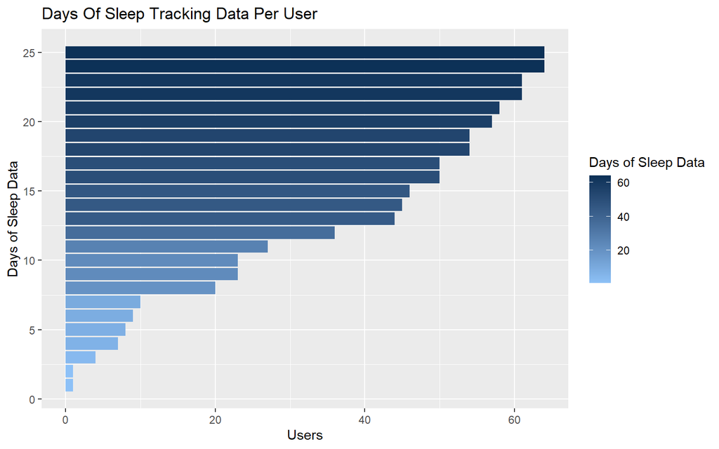

```r
TrackedDays <- DailySleepDF %>% group_by(Id) %>% summarise(days_tracked = n()) %>% arrange(days_tracked)

ggplot(TrackedDays, aes(x = seq_along(days_tracked), y = days_tracked, fill = days_tracked)) +
    geom_col() + coord_flip() +
    labs(x = "Days of Sleep Data", y = "Users", title = "Days Of Sleep Tracking Data Per User",
         fill='Days of Sleep Data') + scale_fill_gradient(low = "#8dc1f7", high = "#0c3157")
```

As the chart indicates, only two participants tracked sleep data for the entire period, with half the participants having less than 40 days of sleep data. This in itself is a valuable insight: Users have difficulty being consistent in their tracking of sleep data.

Some descriptive statistics on key variables follows:

```r
DailyActivityDF %>% select(TotalSteps, TotalDistance, SedentaryMinutes) %>% summary()
```

```
##    TotalSteps    TotalDistance    SedentaryMinutes
##  Min.   :    0   Min.   : 0.000   Min.   :   0.0
##  1st Qu.: 3134   1st Qu.: 2.160   1st Qu.: 728.0
##  Median : 6943   Median : 4.930   Median :1055.0
##  Mean   : 7254   Mean   : 5.199   Mean   : 987.2
##  3rd Qu.:10538   3rd Qu.: 7.485   3rd Qu.:1241.0
##  Max.   :36019   Max.   :28.030   Max.   :1440.0
```

```r
DailySleepDF %>%  select(MinutesAsleep, MinutesInBed) %>% summary()
```

```
##  MinutesAsleep    MinutesInBed
##  Min.   :  6.0   Min.   :  6.0
##  1st Qu.:348.0   1st Qu.:386.0
##  Median :426.0   Median :458.0
##  Mean   :405.2   Mean   :440.7
##  3rd Qu.:492.0   3rd Qu.:523.0
##  Max.   :901.0   Max.   :961.0
```

Some observations:

- Users with fitness trackers walk an average of over 7000 steps, and a distance of over 5 miles per day. This is above the average of [5000 steps per day](https://journals.lww.com/acsm-msse/Fulltext/2010/10000/Pedometer_Measured_Physical_Activity_and_Health.4.aspx). This indicates that people who use fitness trackers tend to be more active.
- Despite an above average level of activity, users still averaged close to 17 hours of inactivity (987 sedentary minutes). Furthermore, recorded over 20 hours of inactivity 25% of the time.
- Average recorded sleep was 6 hours 45 minutes, which is slightly below the minimum recommended time of 7 hours. However, there is large variance in recorded sleep, with the values between the first and third quartiles ranging from 5 hours 48 minutes to 8 hours 12 minutes.

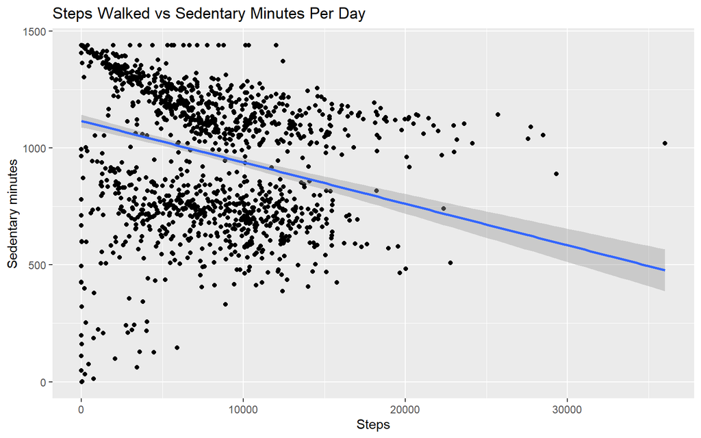

```r
ggplot(DailyActivityDF, aes(x=TotalSteps, y=SedentaryMinutes)) +
  geom_point() + geom_smooth(method = "lm") +
  labs(x = "Steps", y="Sedentary minutes", title = "Steps Walked vs Sedentary Minutes Per Day")
```

While not from the scatter plot, the trend line shows an inverse relationship between steps walked and sedentary minutes.

Let’s explore the relationship between activity and sleep:

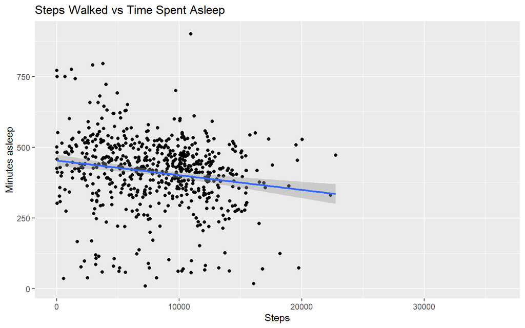

```r
ggplot(DailyActivityDF, aes(x=TotalSteps, y=MinutesAsleep)) +
  geom_point() + geom_smooth(method = "lm") +
  labs(x = "Steps", y = "Minutes asleep", title = "Steps Walked vs Time Spent Asleep")
```

Steps walked also has an inverse relationship with time spent sleeping.

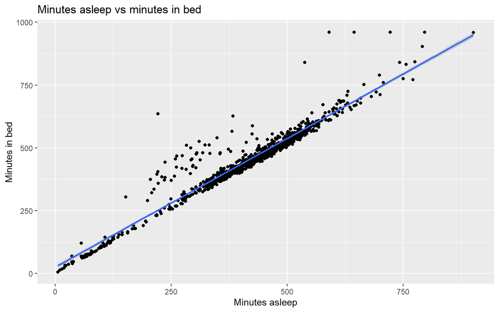

```r
ggplot(DailySleepDF, aes(x=MinutesAsleep, y=MinutesInBed)) + geom_point() + geom_smooth(method = "lm") +
  labs(x = "Minutes asleep", y = "Minutes in bed", title = "Minutes asleep vs minutes in bed")
```

The data indicates a near 1:1 relationship. However, there are clusters of data points that lie far from the trend line. The next chart investigates these outliers further by filtering out data points close to the trend line:

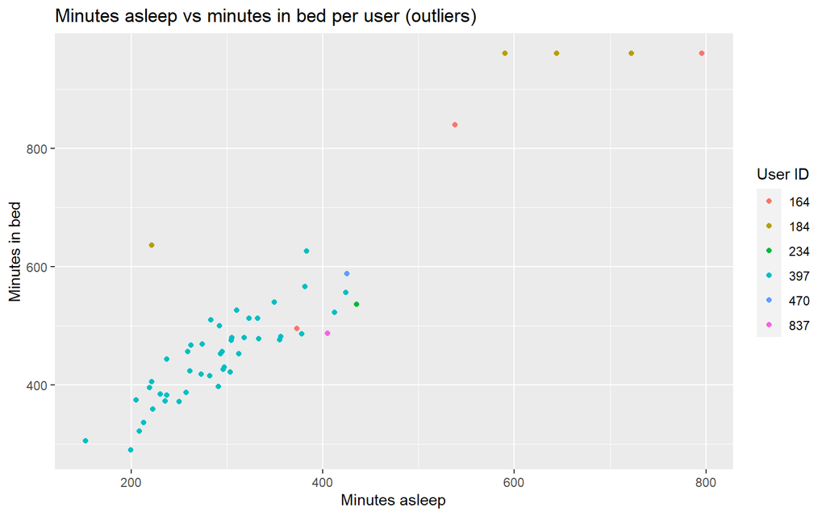

```r
SleepOutliers <- DailySleepDF %>% filter(MinutesInBed/MinutesAsleep > 1.2) %>%
  filter(MinutesAsleep > 120)
ggplot(SleepOutliers, aes(x=MinutesAsleep, y=MinutesInBed, color=as.character(substr(Id,1,3)))) +
  geom_point() + labs(x = "Minutes asleep", y = "Minutes in bed",
                      title = "Minutes asleep vs minutes in bed per user (outliers)", color='User ID')
```

The majority of the data points belong to 2 users: ID codes beginning 184 and 397. This indicates that these particular participants may have sleep-related issues, whilst the majority of users show a good relationship between time in bed and time asleep, with only a few exceptions.

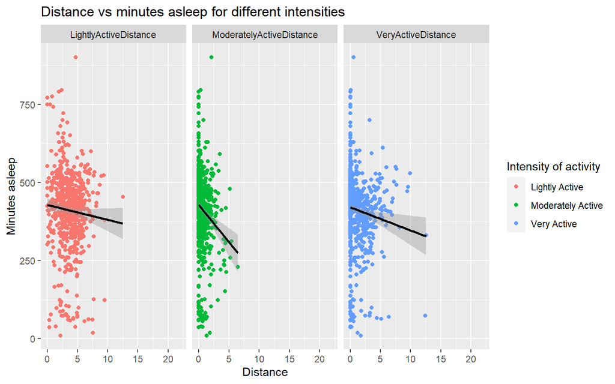

```r
ActivityType <- DailyActivityDF %>%
pivot_longer(cols = c("VeryActiveDistance","ModeratelyActiveDistance","LightlyActiveDistance"),
             names_to = "ActiveType", values_to = "Distance")

ggplot(ActivityType, aes(x=Distance, y=MinutesAsleep, color=ActiveType)) +
  geom_point() + geom_smooth(color="black", method = "lm") + facet_wrap(~ActiveType) +
  labs(x = "Distance", y = "Minutes asleep",
       title = "Distance vs minutes asleep for different intensities", color = "Intensity of activity") +
  scale_color_discrete(labels = c("Lightly Active", "Moderately Active", "Very Active"))
```

While all types of activity result in reduced sleep, moderate activity has the strongest relationship.

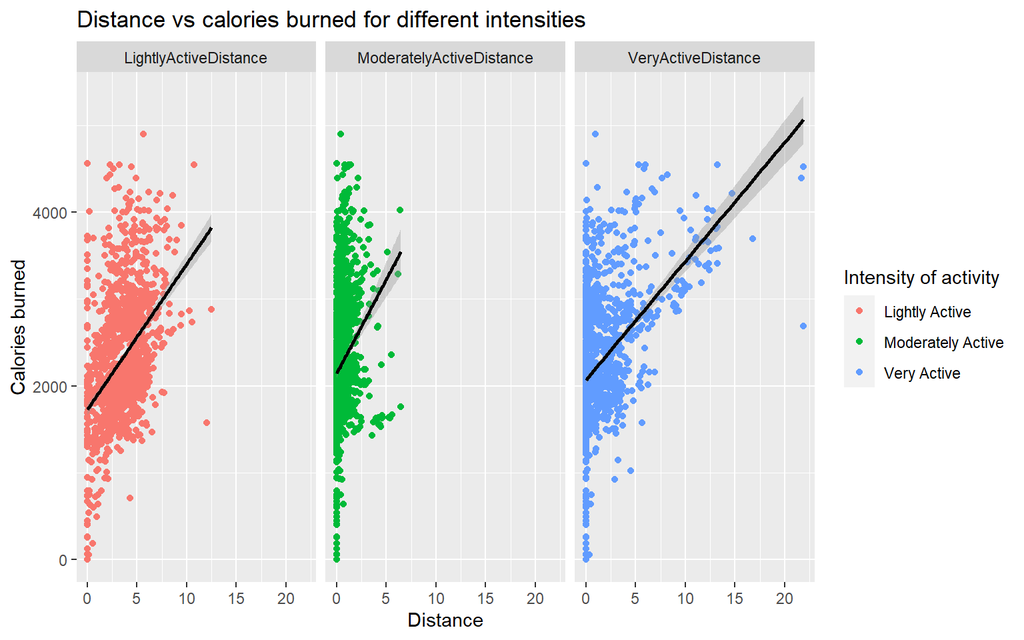

```r
ggplot(ActivityType, aes(x=Distance, y=Calories, color=ActiveType)) +
  geom_point() + geom_smooth(color="black", method = "lm") + facet_wrap(~ActiveType) +
  labs(x = "Distance", y = "Calories burned",
       title = "Distance vs calories burned for different intensities",
       color = "Intensity of activity") +
  scale_color_discrete(labels = c("Lightly Active", "Moderately Active", "Very Active"))
```

Calories burned is a key component in weight management. The chart indicates that increased activity results in increased calories burned, but that the intensity of the activity is less important than the amount.

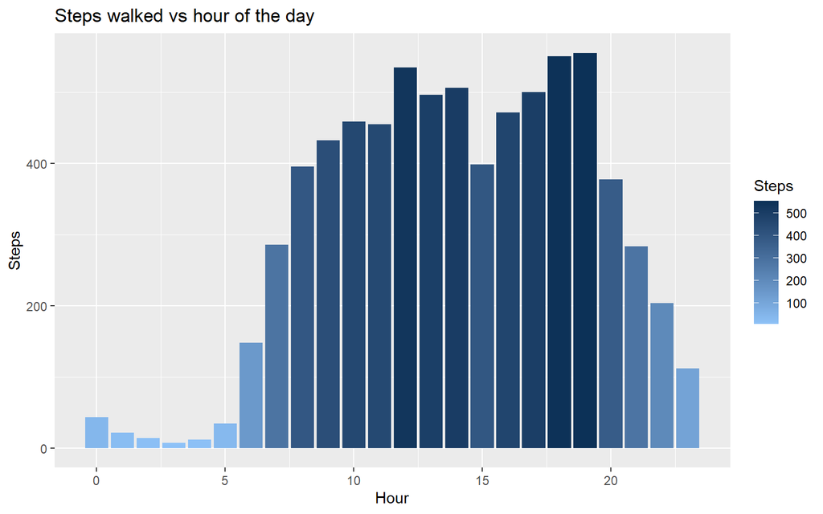

```r
HourlyGrouped <- HourlyActivityDF %>% mutate(Hour = hour(Hour)) %>%
  mutate(MinutesAsleep = if_else(is.na(MinutesAsleep), 0L, MinutesAsleep)) %>% group_by(Hour) %>%
  summarise(Calories = mean(Calories), Steps = mean(TotalSteps), MinutesAsleep = mean(MinutesAsleep))

ggplot(HourlyGrouped, aes(x=Hour, y=Steps, fill=Steps)) + geom_col() +
  labs(title = "Steps walked vs hour of the day") + scale_fill_gradient(low = "#8dc1f7", high = "#0c3157")
```

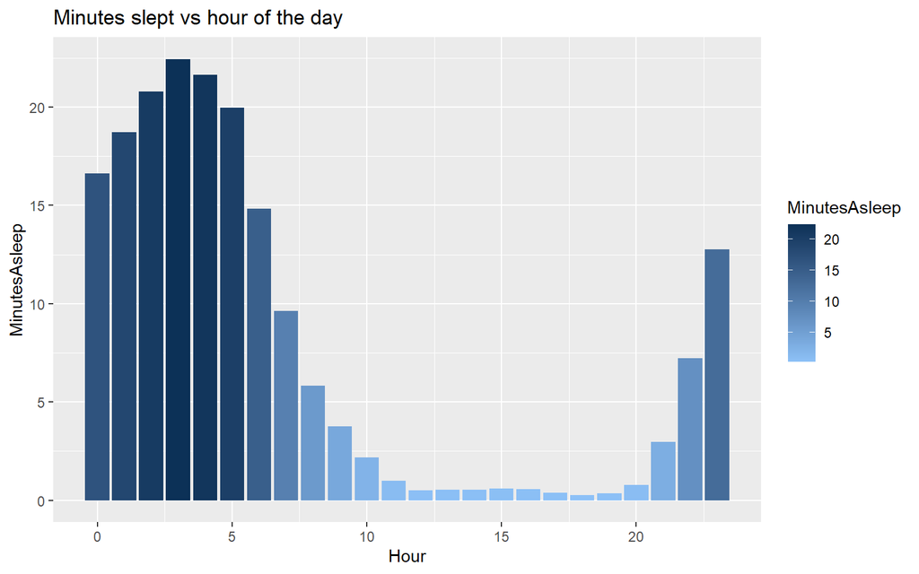

```r
ggplot(HourlyGrouped, aes(x=Hour, y=MinutesAsleep, fill=MinutesAsleep)) + geom_col() +
  labs(title = "Minutes slept vs hour of the day") + scale_fill_gradient(low = "#8dc1f7", high = "#0c3157")
```

The analysis process has produced valuable insights, which will be used to produce recommendations.

## 5: Insights and Recommendations

The key findings to be communicated to the marketing team are summarised below:

- People who use fitness trackers tend to be more active. Using a fitness tracker can help as a motivator for maintaining an active lifestyle.
- A key benefit of being active is related to sleep: higher activity leads to less sleep. Users who maintain a moderate amount of activity meet recommended sleeping behavior.
- Another key benefit is in weight loss and weight regulation: Being active increases calories burned. Amount of activity is far more important than the intensity, and so even light or moderately intense activities are sufficient.
- Using a fitness tracker to measure step count can be a good way to regulate your activity, and thus meet goals for either improving sleep behaviour or weight management.
- Users struggled to consistently track sleep and weight data. Encourage more consistent data tracking through reminders or improved ease of use.